# CENG 4515 DATA SCIENCE AND ANALYTICS

HOMEWORK - 2

Ayşe Ceren Çiçek

Dataset: https://www.kaggle.com/uciml/breast-cancer-wisconsin-data

The columns are:

- id: ID number
- diagnosis: The diagnosis of breast tissues (M = malignant, B = benign)
- radius_mean: mean of distances from center to points on the perimeter
- texture_mean: standard deviation of gray-scale values
- perimeter_mean: mean size of the core tumor

And the other columns are: area_mean, smoothness_mean, compactness_mean, concavity_mean, concave points_mean, symmetry_mean, fractal_dimension_mean, radius_se, texture_se, perimeter_se, area_se, smoothness_se, compactness_se, concavity_se, concave points_se, symmetry_se, fractal_dimension_se, radius_worst, texture_worst, perimeter_worst, area_worst, smoothness_worst, compactness_worst, concavity_worst, concave points_worst, symmetry_worst, fractal_dimension_worst.

## Importing libraries

```r
library(tidyverse)
library(plyr)
library(ggplot2)
library(gplots)
library(caret)
library(ROCR)
library(logistf)
library(PerformanceAnalytics)
library(GGally)
library(corrplot)
library(pheatmap)
library(factoextra)
library(ggfortify)
library(sparklyr)
library(pipeR)
```

## Loading dataset

```r
# Load dataset
data <- read.csv("data.csv")

# Show first 5 columns of the data
head(data, n=5)
```

```
##         id diagnosis radius_mean texture_mean perimeter_mean area_mean
## 1   842302         M       17.99        10.38         122.80    1001.0
## 2   842517         M       20.57        17.77         132.90    1326.0
## 3 84300903         M       19.69        21.25         130.00    1203.0
## 4 84348301         M       11.42        20.38          77.58     386.1
## 5 84358402         M       20.29        14.34         135.10    1297.0
##   smoothness_mean compactness_mean concavity_mean concave.points_mean
## 1         0.11840          0.27760         0.3001             0.14710
## 2         0.08474          0.07864         0.0869             0.07017
## 3         0.10960          0.15990         0.1974             0.12790
## 4         0.14250          0.28390         0.2414             0.10520
## 5         0.10030          0.13280         0.1980             0.10430
##   symmetry_mean fractal_dimension_mean radius_se texture_se perimeter_se
## 1        0.2419                0.07871    1.0950     0.9053        8.589
## 2        0.1812                0.05667    0.5435     0.7339        3.398
```

[output cut: 27 more lines]

# Data preprocessing

Let’s summarize our data.

```r
summary(data)
```

```
##        id             diagnosis          radius_mean      texture_mean
##  Min.   :     8670   Length:569         Min.   : 6.981   Min.   : 9.71
##  1st Qu.:   869218   Class :character   1st Qu.:11.700   1st Qu.:16.17
##  Median :   906024   Mode  :character   Median :13.370   Median :18.84
##  Mean   : 30371831                      Mean   :14.127   Mean   :19.29
##  3rd Qu.:  8813129                      3rd Qu.:15.780   3rd Qu.:21.80
##  Max.   :911320502                      Max.   :28.110   Max.   :39.28
##  perimeter_mean     area_mean      smoothness_mean   compactness_mean
##  Min.   : 43.79   Min.   : 143.5   Min.   :0.05263   Min.   :0.01938
##  1st Qu.: 75.17   1st Qu.: 420.3   1st Qu.:0.08637   1st Qu.:0.06492
##  Median : 86.24   Median : 551.1   Median :0.09587   Median :0.09263
##  Mean   : 91.97   Mean   : 654.9   Mean   :0.09636   Mean   :0.10434
##  3rd Qu.:104.10   3rd Qu.: 782.7   3rd Qu.:0.10530   3rd Qu.:0.13040
##  Max.   :188.50   Max.   :2501.0   Max.   :0.16340   Max.   :0.34540
##  concavity_mean    concave.points_mean symmetry_mean    fractal_dimension_mean
##  Min.   :0.00000   Min.   :0.00000     Min.   :0.1060   Min.   :0.04996
##  1st Qu.:0.02956   1st Qu.:0.02031     1st Qu.:0.1619   1st Qu.:0.05770
##  Median :0.06154   Median :0.03350     Median :0.1792   Median :0.06154
##  Mean   :0.08880   Mean   :0.04892     Mean   :0.1812   Mean   :0.06280
##  3rd Qu.:0.13070   3rd Qu.:0.07400     3rd Qu.:0.1957   3rd Qu.:0.06612
##  Max.   :0.42680   Max.   :0.20120     Max.   :0.3040   Max.   :0.09744
##    radius_se        texture_se      perimeter_se       area_se
##  Min.   :0.1115   Min.   :0.3602   Min.   : 0.757   Min.   :  6.802
##  1st Qu.:0.2324   1st Qu.:0.8339   1st Qu.: 1.606   1st Qu.: 17.850
##  Median :0.3242   Median :1.1080   Median : 2.287   Median : 24.530
##  Mean   :0.4052   Mean   :1.2169   Mean   : 2.866   Mean   : 40.337
##  3rd Qu.:0.4789   3rd Qu.:1.4740   3rd Qu.: 3.357   3rd Qu.: 45.190
##  Max.   :2.8730   Max.   :4.8850   Max.   :21.980   Max.   :542.200
##  smoothness_se      compactness_se      concavity_se     concave.points_se
##  Min.   :0.001713   Min.   :0.002252   Min.   :0.00000   Min.   :0.000000
##  1st Qu.:0.005169   1st Qu.:0.013080   1st Qu.:0.01509   1st Qu.:0.007638
##  Median :0.006380   Median :0.020450   Median :0.02589   Median :0.010930
##  Mean   :0.007041   Mean   :0.025478   Mean   :0.03189   Mean   :0.011796
##  3rd Qu.:0.008146   3rd Qu.:0.032450   3rd Qu.:0.04205   3rd Qu.:0.014710
##  Max.   :0.031130   Max.   :0.135400   Max.   :0.39600   Max.   :0.052790
##   symmetry_se       fractal_dimension_se  radius_worst   texture_worst
##  Min.   :0.007882   Min.   :0.0008948    Min.   : 7.93   Min.   :12.02
##  1st Qu.:0.015160   1st Qu.:0.0022480    1st Qu.:13.01   1st Qu.:21.08
##  Median :0.018730   Median :0.0031870    Median :14.97   Median :25.41
##  Mean   :0.020542   Mean   :0.0037949    Mean   :16.27   Mean   :25.68
```

[output cut: 8 more lines]

```
##  Max.   :251.20   Max.   :4254.0   Max.   :0.22260   Max.   :1.05800
##  concavity_worst  concave.points_worst symmetry_worst   fractal_dimension_worst
##  Min.   :0.0000   Min.   :0.00000      Min.   :0.1565   Min.   :0.05504
##  1st Qu.:0.1145   1st Qu.:0.06493      1st Qu.:0.2504   1st Qu.:0.07146
##  Median :0.2267   Median :0.09993      Median :0.2822   Median :0.08004
##  Mean   :0.2722   Mean   :0.11461      Mean   :0.2901   Mean   :0.08395
##  3rd Qu.:0.3829   3rd Qu.:0.16140      3rd Qu.:0.3179   3rd Qu.:0.09208
##  Max.   :1.2520   Max.   :0.29100      Max.   :0.6638   Max.   :0.20750
##     X
##  Mode:logical
##  NA's:569
##
##
##
##
```

The original dataset does not contain the X columns we will remove it.

```r
data <- subset(data, select=-X)
```

```r
# Check null values
which(is.na(data))
```

```
## integer(0)
```

We will remove id column and replace diagnosis values B with 0 and M with 1.

```r
data$id <- NULL
data$diagnosis <- ifelse(data$diagnosis == "B", 0, 1)
```

Let’s check column types.

```r
sapply(data, class)
```

```
##               diagnosis             radius_mean            texture_mean
##               "numeric"               "numeric"               "numeric"
##          perimeter_mean               area_mean         smoothness_mean
##               "numeric"               "numeric"               "numeric"
##        compactness_mean          concavity_mean     concave.points_mean
##               "numeric"               "numeric"               "numeric"
##           symmetry_mean  fractal_dimension_mean               radius_se
##               "numeric"               "numeric"               "numeric"
##              texture_se            perimeter_se                 area_se
##               "numeric"               "numeric"               "numeric"
##           smoothness_se          compactness_se            concavity_se
##               "numeric"               "numeric"               "numeric"
##       concave.points_se             symmetry_se    fractal_dimension_se
##               "numeric"               "numeric"               "numeric"
##            radius_worst           texture_worst         perimeter_worst
##               "numeric"               "numeric"               "numeric"
##              area_worst        smoothness_worst       compactness_worst
##               "numeric"               "numeric"               "numeric"
##         concavity_worst    concave.points_worst          symmetry_worst
##               "numeric"               "numeric"               "numeric"
## fractal_dimension_worst
##               "numeric"
```

All of the columns seems numeric so we can draw a heatmap.

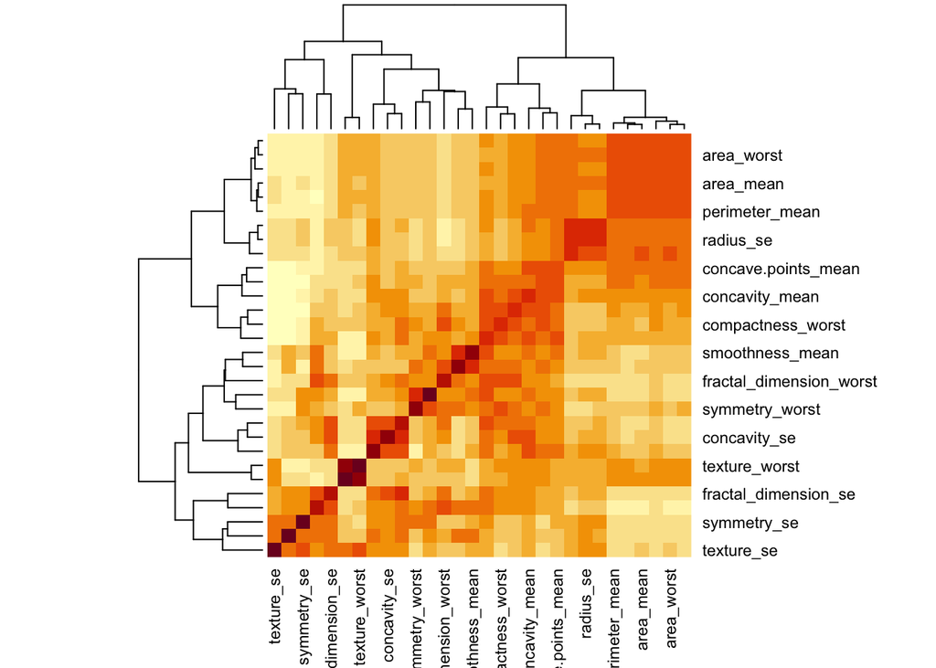

```r
heatmap(cor(data[,-1]))
```

```r
data_corr = cbind(diagnosis=data[,c(1)], data[,c(22:31)])
```

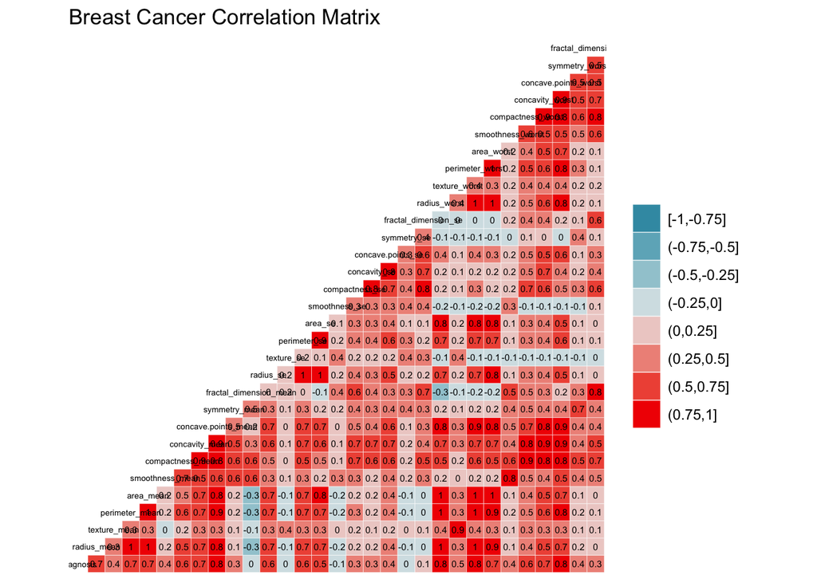

```r
# Draw correlation matrix
ggcorr(data, nbreaks=8, label=TRUE, label_size=2, size = 1.8, type = "upper", order = "hclust",
         tl.col = "black", tl.srt = 45) + ggtitle("Breast Cancer Correlation Matrix")
```

```r
corr_data = cor(data)

corr_data = round(corr_data, 4)

# Remove low relationship
corr_data[abs(corr_data) < 0.7] = NA

# Drop duplicates and meaningless information
corr_data[lower.tri(corr_data, diag = TRUE)] = NA

# Turn it into a 3-column table
corr_data=as.data.frame(as.table(corr_data))
corr_data=na.omit(corr_data)

#Sort by highest correlation
corr_data=corr_data[order(-abs(corr_data$Freq)),]
corr_data
```

```
##                       Var1                    Var2   Freq
## 95             radius_mean          perimeter_mean 0.9979
## 735           radius_worst         perimeter_worst 0.9937
## 126            radius_mean               area_mean 0.9874
## 128         perimeter_mean               area_mean 0.9865
## 766           radius_worst              area_worst 0.9840
## 768        perimeter_worst              area_worst 0.9776
## 415              radius_se            perimeter_se 0.9728
## 717         perimeter_mean         perimeter_worst 0.9704
## 653            radius_mean            radius_worst 0.9695
## 655         perimeter_mean            radius_worst 0.9695
## 715            radius_mean         perimeter_worst 0.9651
## 656              area_mean            radius_worst 0.9627
## 749              area_mean              area_worst 0.9592
## 718              area_mean         perimeter_worst 0.9591
```

[output cut: 64 more lines]

## Building a logistic regression model (Base model)

```r
set.seed(123)

# Train test split
splitted<-createDataPartition(data$diagnosis, p=0.8, list=FALSE)

# Train data
X_train<-data[splitted,-1]
y_train<-data$diagnosis[splitted]

# Test data
X_test<-data[-splitted,-1]
y_test<-data$diagnosis[-splitted]
```

```r
# Logistic regression model with all variables
model <- glm(formula = y_train ~ ., family = binomial, data = X_train)
summary(model)
```

```
##
## Call:
## glm(formula = y_train ~ ., family = binomial, data = X_train)
##
## Deviance Residuals:
##        Min          1Q      Median          3Q         Max
## -5.173e-04  -2.000e-08  -2.000e-08   2.000e-08   4.794e-04
##
## Coefficients:
##                           Estimate Std. Error z value Pr(>|z|)
## (Intercept)             -3.287e+03  7.996e+05  -0.004    0.997
## radius_mean             -2.209e+03  2.274e+05  -0.010    0.992
## texture_mean             6.285e+00  4.912e+03   0.001    0.999
## perimeter_mean           2.058e+02  3.914e+04   0.005    0.996
## area_mean                8.404e+00  6.371e+02   0.013    0.989
## smoothness_mean          1.435e+04  1.228e+06   0.012    0.991
## compactness_mean        -1.521e+04  1.470e+06  -0.010    0.992
## concavity_mean           1.890e+03  1.522e+06   0.001    0.999
## concave.points_mean      4.356e+03  1.199e+06   0.004    0.997
## symmetry_mean           -3.595e+03  7.549e+05  -0.005    0.996
## fractal_dimension_mean   2.888e+04  4.501e+06   0.006    0.995
## radius_se                1.055e+03  7.243e+05   0.001    0.999
## texture_se              -2.333e+01  1.865e+04  -0.001    0.999
## perimeter_se            -1.639e+02  4.275e+04  -0.004    0.997
## area_se                  1.194e+01  4.722e+03   0.003    0.998
## smoothness_se           -4.494e+03  8.402e+06  -0.001    1.000
## compactness_se           2.444e+04  1.020e+06   0.024    0.981
## concavity_se            -1.403e+04  9.597e+05  -0.015    0.988
## concave.points_se        6.006e+04  5.239e+06   0.011    0.991
## symmetry_se             -1.535e+04  1.986e+06  -0.008    0.994
## fractal_dimension_se    -2.101e+05  1.304e+07  -0.016    0.987
## radius_worst             6.994e+02  5.604e+04   0.012    0.990
## texture_worst            2.482e+01  4.877e+03   0.005    0.996
## perimeter_worst         -1.389e+01  4.280e+03  -0.003    0.997
## area_worst              -4.243e+00  3.789e+02  -0.011    0.991
## smoothness_worst        -2.654e+03  5.707e+05  -0.005    0.996
## compactness_worst       -1.571e+03  2.006e+05  -0.008    0.994
## concavity_worst          2.079e+03  3.128e+05   0.007    0.995
## concave.points_worst     1.468e+03  4.865e+05   0.003    0.998
## symmetry_worst           3.461e+03  4.707e+05   0.007    0.994
## fractal_dimension_worst  9.239e+03  1.239e+06   0.007    0.994
##
## (Dispersion parameter for binomial family taken to be 1)
##
##     Null deviance: 5.8973e+02  on 455  degrees of freedom
## Residual deviance: 2.4836e-06  on 425  degrees of freedom
## AIC: 62
##
## Number of Fisher Scoring iterations: 25
```

```r
# Subset without correlated variables
subset.data<-subset(data, select=-c(area_mean,radius_mean,area_worst,compactness_mean,perimeter_worst,compactness_se,concavity_worst,fractal_dimension_worst))
```

```r
# Train data
X_train<-subset.data[splitted,-1]
y_train<-subset.data$diagnosis[splitted]

# Test data
X_test<-subset.data[-splitted,-1]
y_test<-subset.data$diagnosis[-splitted]
```

```r
# Logistic regression model without correlated variables
model <- glm(formula = y_train ~ ., family = binomial, data = X_train)
summary(model)
```

```
##
## Call:
## glm(formula = y_train ~ ., family = binomial, data = X_train)
##
## Deviance Residuals:
##     Min       1Q   Median       3Q      Max
## -1.8045  -0.0105  -0.0004   0.0000   3.5649
##
## Coefficients:
##                         Estimate Std. Error z value Pr(>|z|)
## (Intercept)             -46.5868    23.8636  -1.952   0.0509 .
## texture_mean             -0.0385     0.3875  -0.099   0.9208
## perimeter_mean           -0.3749     0.2184  -1.716   0.0861 .
## smoothness_mean         -46.1600   122.3227  -0.377   0.7059
## concavity_mean           58.6424    49.5029   1.185   0.2362
## concave.points_mean      58.3458   121.9918   0.478   0.6325
## symmetry_mean           -30.3322    40.9067  -0.741   0.4584
## fractal_dimension_mean   37.5853   240.7157   0.156   0.8759
## radius_se                13.8062    28.8093   0.479   0.6318
## texture_se               -2.1499     2.5129  -0.856   0.3923
## perimeter_se             -1.3086     1.7179  -0.762   0.4462
## area_se                   0.1569     0.2734   0.574   0.5660
## smoothness_se            97.8689   404.7136   0.242   0.8089
## concavity_se            -47.0931    66.7983  -0.705   0.4808
## concave.points_se       325.8580   423.7169   0.769   0.4419
## symmetry_se            -185.0452   147.9911  -1.250   0.2112
## fractal_dimension_se   -693.9033   705.8786  -0.983   0.3256
## radius_worst              2.8492     1.3694   2.081   0.0375 *
## texture_worst             0.5715     0.3853   1.483   0.1380
## smoothness_worst         40.0156    83.4601   0.479   0.6316
## compactness_worst        -6.9451    10.4466  -0.665   0.5062
## concave.points_worst     28.6680    46.4424   0.617   0.5370
## symmetry_worst           43.6455    26.8224   1.627   0.1037
## ---
## Signif. codes:  0 '***' 0.001 '**' 0.01 '*' 0.05 '.' 0.1 ' ' 1
##
## (Dispersion parameter for binomial family taken to be 1)
##
##     Null deviance: 589.725  on 455  degrees of freedom
## Residual deviance:  42.525  on 433  degrees of freedom
## AIC: 88.525
##
## Number of Fisher Scoring iterations: 11
```

```r
anova(model)
```

```
## Analysis of Deviance Table
##
## Model: binomial, link: logit
##
## Response: y_train
##
## Terms added sequentially (first to last)
##
##
##                        Df Deviance Resid. Df Resid. Dev
## NULL                                     455     589.73
## texture_mean            1   89.341       454     500.38
## perimeter_mean          1  280.000       453     220.38
## smoothness_mean         1   70.695       452     149.69
## concavity_mean          1   13.223       451     136.47
## concave.points_mean     1    3.135       450     133.33
## symmetry_mean           1    2.027       449     131.31
## fractal_dimension_mean  1    3.020       448     128.29
## radius_se               1    0.079       447     128.21
## texture_se              1   10.767       446     117.44
## perimeter_se            1    0.012       445     117.43
## area_se                 1    8.904       444     108.52
## smoothness_se           1    4.131       443     104.39
## concavity_se            1   14.417       442      89.97
## concave.points_se       1    0.707       441      89.27
## symmetry_se             1    0.468       440      88.80
## fractal_dimension_se    1    2.549       439      86.25
## radius_worst            1   29.170       438      57.08
## texture_worst           1    7.951       437      49.13
## smoothness_worst        1    2.077       436      47.05
## compactness_worst       1    0.010       435      47.04
## concave.points_worst    1    0.284       434      46.76
## symmetry_worst          1    4.233       433      42.53
```

```r
# Make predictions
prediction <- ifelse(predict(object=model, newdata=X_test, type = "response") > 0.5, 1, 0)

# Generate confusion matrix
conf.matrix <- confusionMatrix(table(prediction, y_test), positive="1")
conf.matrix
```

```
## Confusion Matrix and Statistics
##
##           y_test
## prediction  0  1
##          0 59  0
##          1  1 53
##
##                Accuracy : 0.9912
##                  95% CI : (0.9517, 0.9998)
##     No Information Rate : 0.531
##     P-Value [Acc > NIR] : <2e-16
##
##                   Kappa : 0.9823
##
##  Mcnemar's Test P-Value : 1
##
##             Sensitivity : 1.0000
##             Specificity : 0.9833
##          Pos Pred Value : 0.9815
##          Neg Pred Value : 1.0000
##              Prevalence : 0.4690
##          Detection Rate : 0.4690
##    Detection Prevalence : 0.4779
##       Balanced Accuracy : 0.9917
##
##        'Positive' Class : 1
##
```

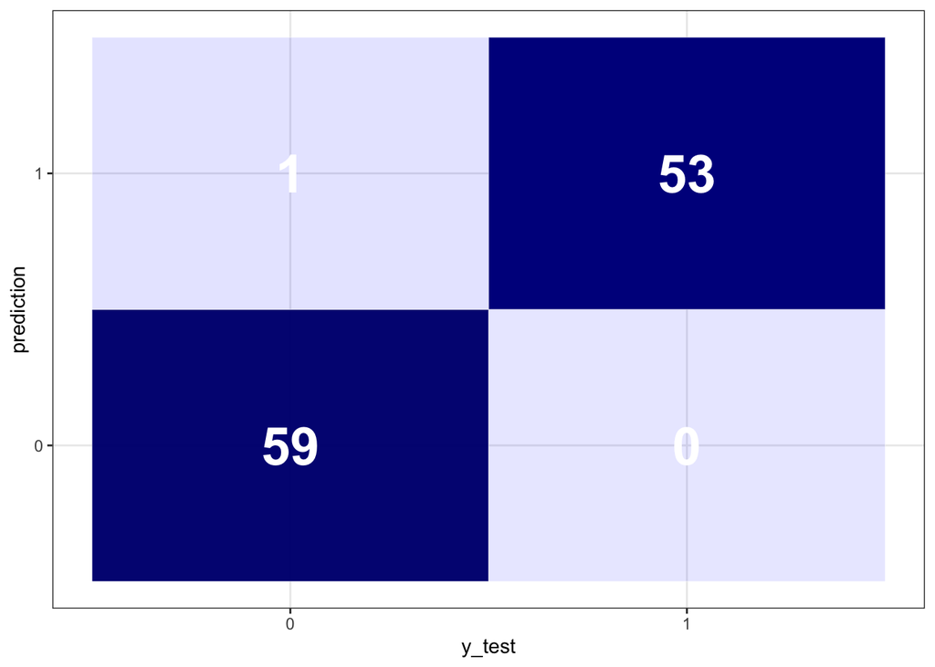

```r
# Heatmap visualization of confusion matrix
table <- data.frame(conf.matrix$table)

plotTable <- table %>%
  group_by(y_test) %>%
  mutate(prop = Freq/sum(Freq))

ggplot(data =  plotTable, mapping = aes(x = y_test, y = prediction, alpha = prop)) +
  geom_tile(aes(fill = Freq), colour = "white") +
  geom_text(aes(label = Freq), vjust = .5, fontface  = "bold", alpha = 1, color="white", size=10) +
  scale_fill_gradient(low = "blue", high = "navyblue") +
  theme_bw() + theme(legend.position = "none")
```

## Applying PCA

```r
# Feature scaling
scale(X_train)
scale(X_test)
```

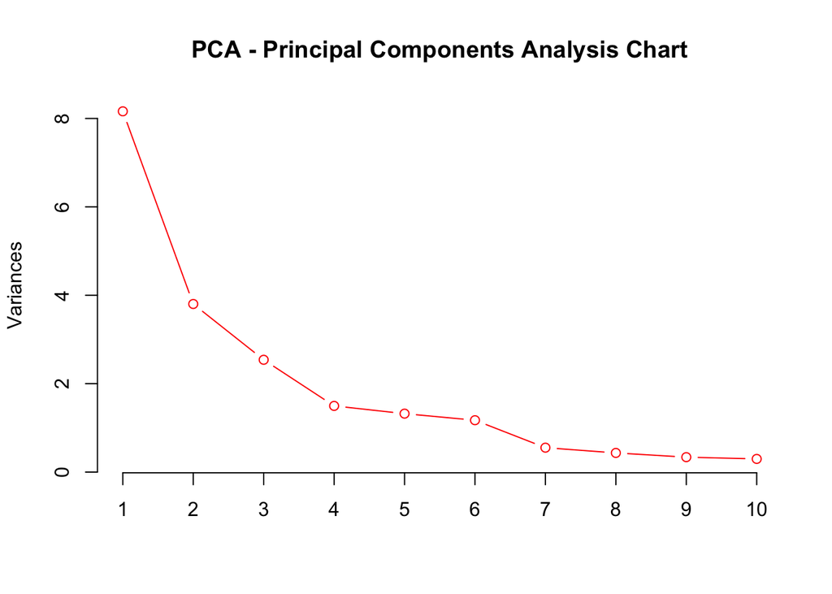

```r
# Apply PCA
pca <- prcomp(X_train[,2:ncol(X_train)],center = TRUE, scale=TRUE)
pca_test<-prcomp(X_test[,2:ncol(X_test)],center = TRUE, scale=TRUE)

# Plot PCA
plot(pca, type='l', main="PCA - Principal Components Analysis Chart", col="red")
```

```r
#Get eigenvalues
explained.variance <- pca$sdev^2
explained.variance
```

```
##  [1] 8.161794359 3.802919958 2.540788132 1.497432787 1.322019908 1.173407576
##  [7] 0.552334177 0.433530285 0.337795611 0.297855565 0.231161903 0.183341020
## [13] 0.126409641 0.103058296 0.068213127 0.052213819 0.042929569 0.029324067
## [19] 0.021269079 0.012522439 0.009678682
```

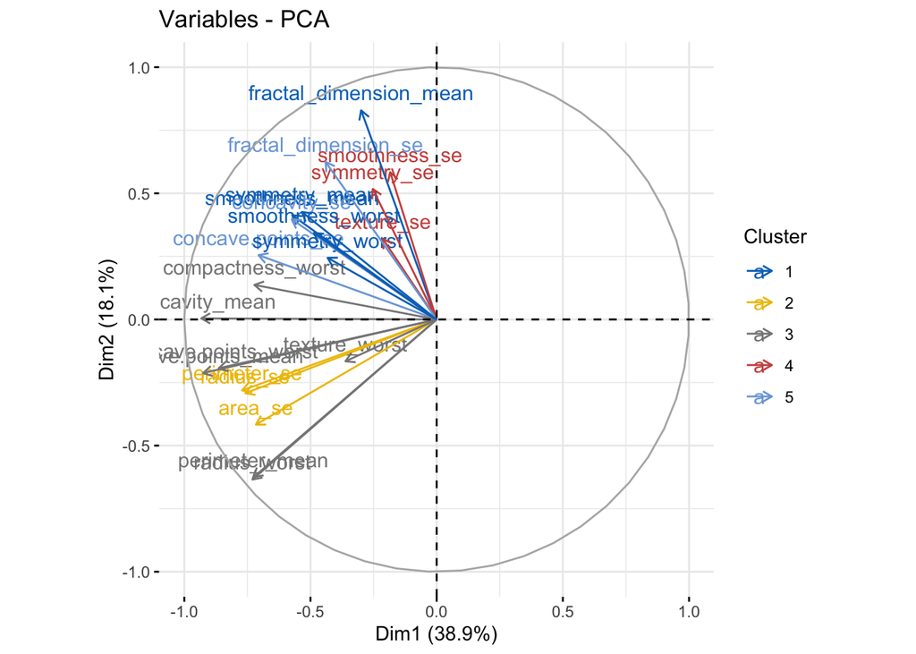

```r
# Plot PCA
pca.var <- get_pca_var(pca)

kmean <- kmeans(pca.var$coord, centers = 5, nstart=25)
group <- as.factor(kmean$cluster)

fviz_pca_var(pca, col.var=group, palette='jco', legend.title='Cluster')
```

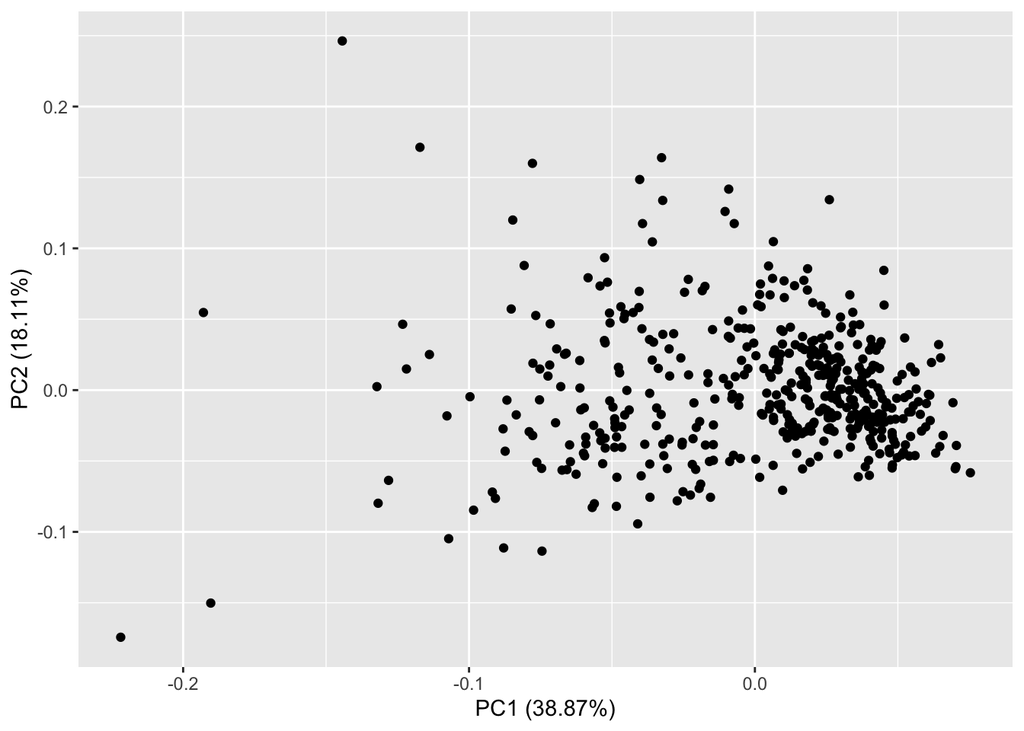

```r
# Plot PCA
autoplot(pca, data = X_train)
```

## Building a logistic regression model on the transformed data

```r
# Logistic regression model
model_pca <- glm(y_train ~ .-PC11 -PC6 -PC8 -PC10 -PC5 -PC9 -PC13 -PC14 -PC12 -PC7,family=binomial, data=pca$x[, c(1:14)] %>% data.frame())
summary(model_pca)
```

```
##
## Call:
## glm(formula = y_train ~ . - PC11 - PC6 - PC8 - PC10 - PC5 - PC9 -
##     PC13 - PC14 - PC12 - PC7, family = binomial, data = pca$x[,
##     c(1:14)] %>% data.frame())
##
## Deviance Residuals:
##      Min        1Q    Median        3Q       Max
## -2.15520  -0.10527  -0.01852   0.00325   2.86887
##
## Coefficients:
##             Estimate Std. Error z value Pr(>|z|)
## (Intercept)  -0.7321     0.3082  -2.375  0.01754 *
## PC1          -2.7938     0.3995  -6.994 2.67e-12 ***
## PC2          -2.2218     0.3818  -5.819 5.90e-09 ***
## PC3           0.4282     0.2163   1.980  0.04771 *
## PC4          -0.8620     0.3312  -2.602  0.00926 **
## ---
## Signif. codes:  0 '***' 0.001 '**' 0.01 '*' 0.05 '.' 0.1 ' ' 1
##
## (Dispersion parameter for binomial family taken to be 1)
##
##     Null deviance: 589.725  on 455  degrees of freedom
## Residual deviance:  87.018  on 451  degrees of freedom
## AIC: 97.018
##
## Number of Fisher Scoring iterations: 9
```

```r
# Make prediction
prediction.pca <- ifelse(predict(model_pca) > 0.5,1,0)

# Generate confusion matrix
conf.matrix.pca <- confusionMatrix(table(prediction.pca, y_train), positive="1")
conf.matrix.pca
```

```
## Confusion Matrix and Statistics
##
##               y_train
## prediction.pca   0   1
##              0 292  13
##              1   5 146
##
##                Accuracy : 0.9605
##                  95% CI : (0.9383, 0.9764)
##     No Information Rate : 0.6513
##     P-Value [Acc > NIR] : < 2e-16
##
##                   Kappa : 0.9121
##
##  Mcnemar's Test P-Value : 0.09896
##
##             Sensitivity : 0.9182
##             Specificity : 0.9832
##          Pos Pred Value : 0.9669
##          Neg Pred Value : 0.9574
##              Prevalence : 0.3487
##          Detection Rate : 0.3202
##    Detection Prevalence : 0.3311
##       Balanced Accuracy : 0.9507
##
##        'Positive' Class : 1
##
```

```r
conf.matrix.pca$table
```

```
##               y_train
## prediction.pca   0   1
##              0 292  13
##              1   5 146
```

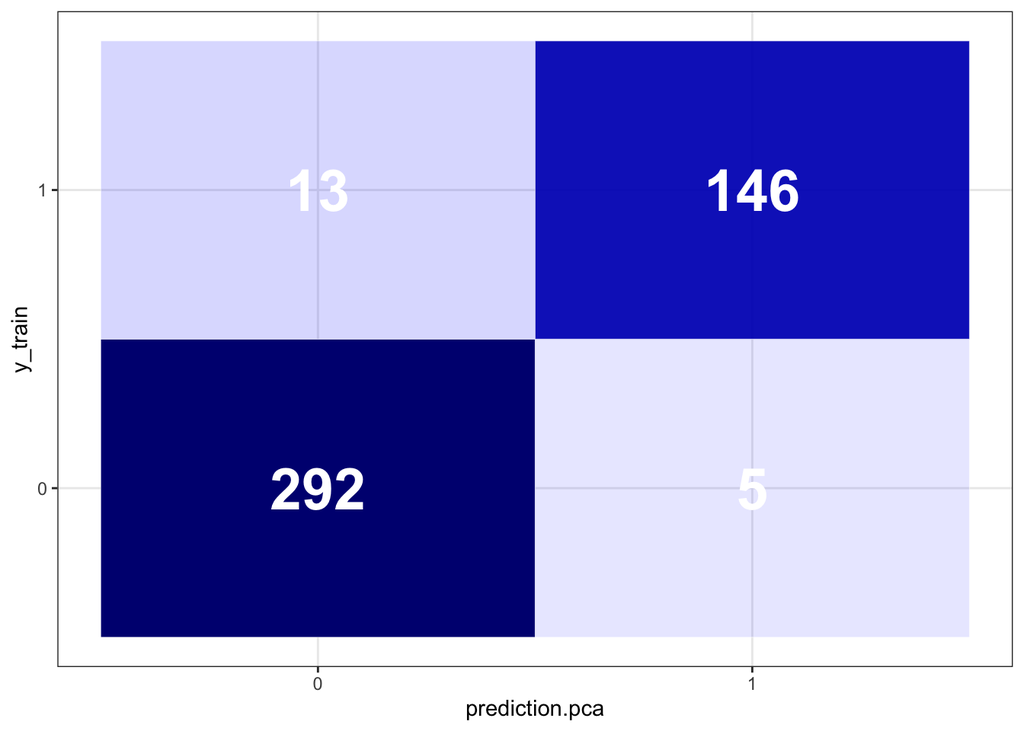

```r
# Heatmap visualization of the confusion matrix
table.pca <- data.frame(conf.matrix.pca$table)

plotTablePCA <- table.pca %>%
  group_by(y_train) %>%
  mutate(prop = Freq/sum(Freq))

ggplot(data =  plotTablePCA, mapping = aes(x = prediction.pca, y = y_train, alpha = prop)) +
  geom_tile(aes(fill = Freq), colour = "white") +
  geom_text(aes(label = Freq), vjust = .5, fontface  = "bold", alpha = 1, color="white", size=10) +
  scale_fill_gradient(low = "blue", high = "navyblue") +
  theme_bw() + theme(legend.position = "none")
```

## Building a machine learning Pipeline

```r
X_train_scaled = scale(X_train)
log.rec.model <- trainControl(method = "glm")
pca.model <- trainControl(method = "prcomp")

#log_reg_model <-  pipeline(X_train_scaled, pca.model, log.rec.model)


#sc <- spark_connect(master = "local", spark_version = "2.2.0")


# pipeline <- ml_pipeline(sc) %>%
#   ft_dplyr_transformer(
#     tbl = pca
#     ) %>%
#   ml_logistic_regression()
```